# Reporte de Fecundidad y Maternidad en Chile

Generado por Fec-Mat CL

23 de junio de 2025

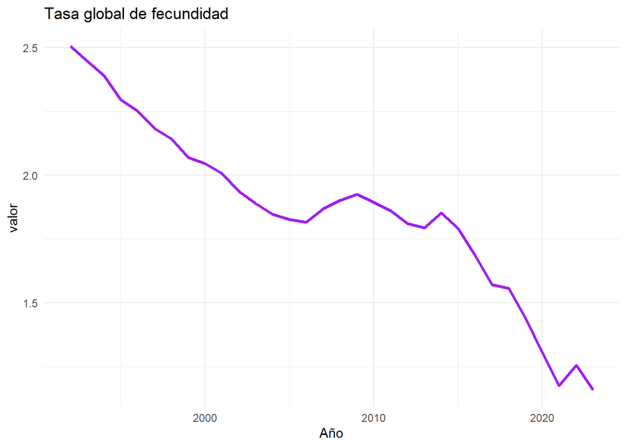

Entre 1992 y 2023, la **Tasa Global de Fecundidad (TGF)** experimentó una disminución, pasando de 2.505 a 1.159. Esta variación puede considerarse considerablemente desde una perspectiva demográfica.

Una TGF de 1.159 indica que, en promedio, una mujer tendría 1 hijos durante su vida fértil si se mantuvieran las tasas actuales. Este valor está por debajo del umbral de reemplazo generacional, lo que sugiere una tendencia hacia el envejecimiento poblacional y una posible reducción futura de la población si no existen flujos migratorios compensatorios.

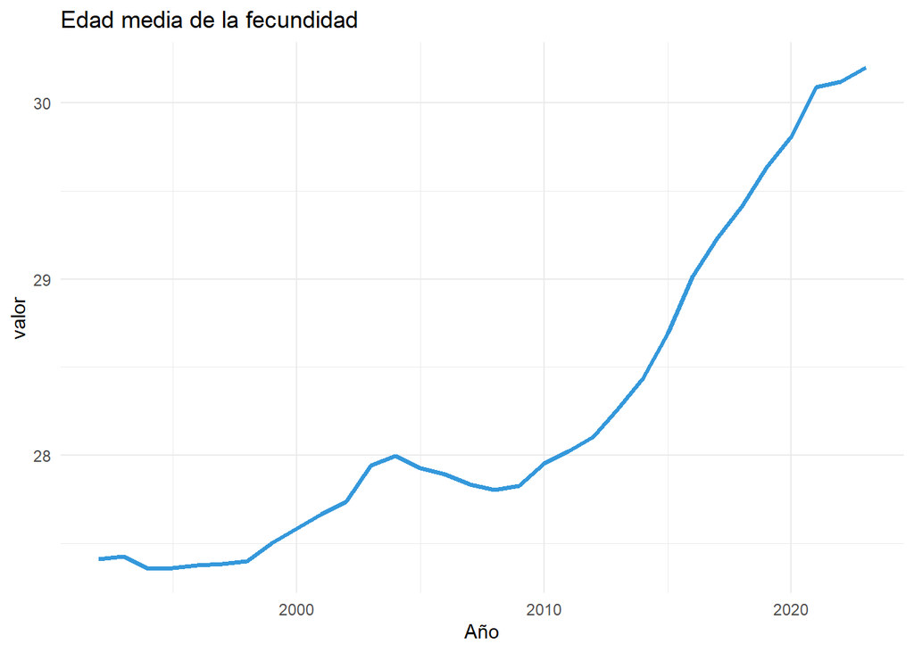

Entre 1992 y 2023, la **Edad Media de la Fecundidad** ha aumentado en 2.79 años, pasando de 27.4121613590153 a 30.2 años. Este incremento sugiere una postergación del inicio de la maternidad, posiblemente asociada a factores como el aumento en la participación laboral femenina, mayores niveles educativos, cambios culturales y/o condiciones económicas que incentivan la planificación familiar en edades más avanzadas. Cabe destacar que este análisis es de carácter descriptivo y no implica una relación causal. Para confirmar estos patrones, se requiere un análisis más exhaustivo mediante técnicas inferenciales o multivariadas apropiadas.

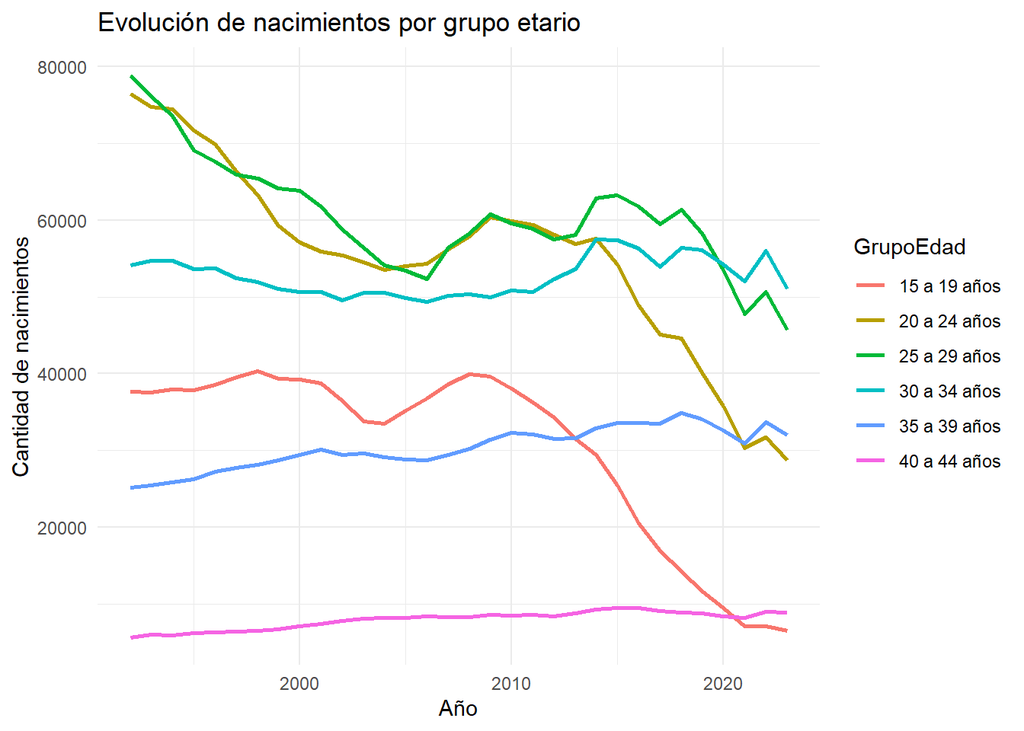

El gráfico muestra la evolución de los nacimientos anuales en Chile según grupo etario de la madre, para los rangos entre **15 y 44 años**. Entre 1992 y 2023, el número total de nacimientos en estos grupos disminuyó en 104942 nacimientos. El grupo con mayor descenso fue el de mujeres de **20 a 24 años**, con una reducción de 47648 nacimientos. Por otro lado, el grupo de **35 a 39 años** registró el mayor incremento, con 6852 nacimientos adicionales.

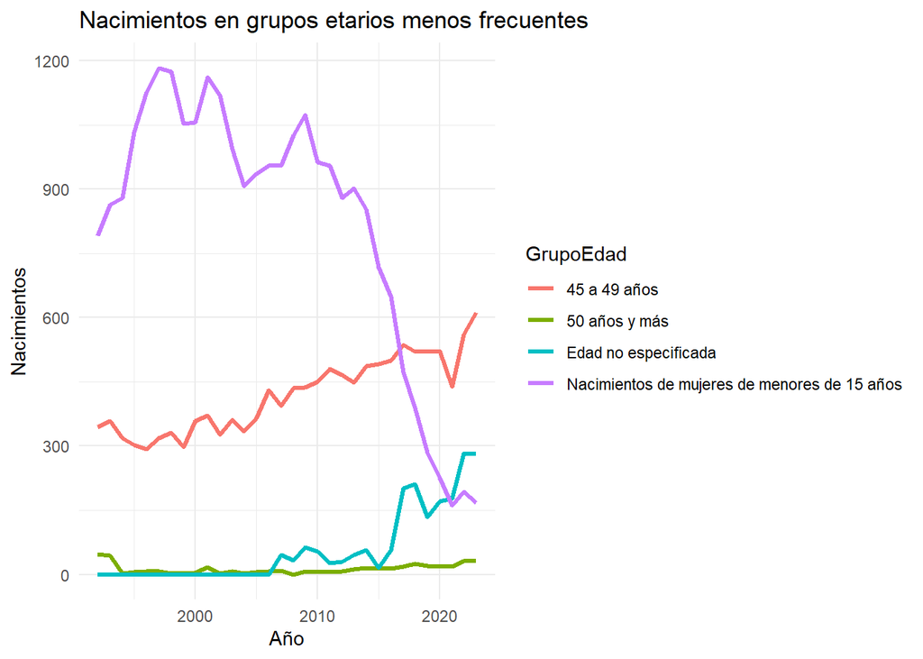

El gráfico muestra la evolución de los nacimientos anuales en Chile para grupos etarios menos frecuentes, como mujeres menores de 15 años, mayores de 45 y casos con edad no especificada. El grupo **45 a 49 años** presentó un aumento de 268 nacimientos entre 1992 y 2023. El grupo **50 años y más** presentó un descenso de 16 nacimientos entre 1992 y 2023. El grupo **Edad no especificada** presentó un aumento de 282 nacimientos entre 1992 y 2023. El grupo **Nacimientos de mujeres de menores de 15 años** presentó un descenso de 623 nacimientos entre 1992 y 2023.

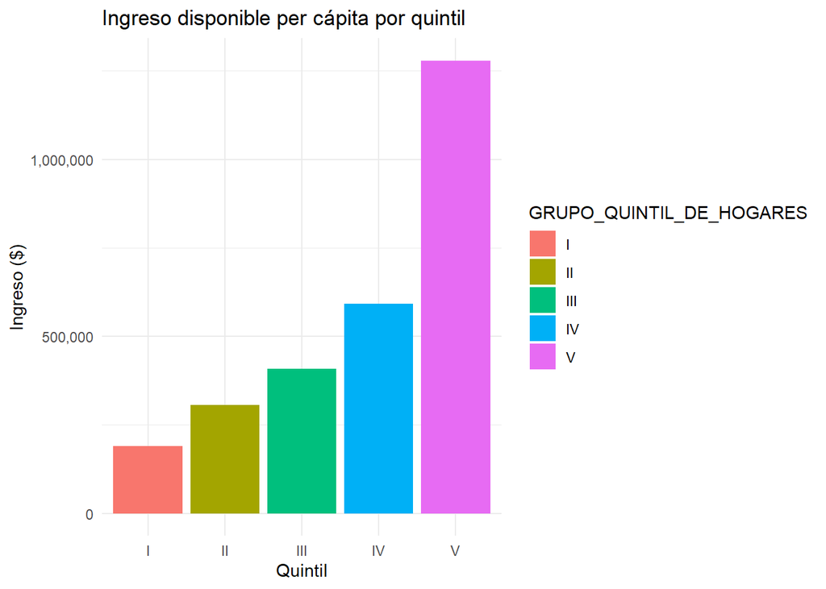

Se observa una marcada desigualdad en los ingresos per cápita entre los quintiles. El grupo con menor ingreso es el quintil I, con un promedio de $190.432, mientras que el más alto corresponde al quintil V, con $1.278.988. Esto implica que el ingreso promedio del quintil superior es aproximadamente 6.7 veces mayor al del quintil inferior, evidenciando una brecha significativa que puede influir en las decisiones de planificación familiar y bienestar general del hogar.

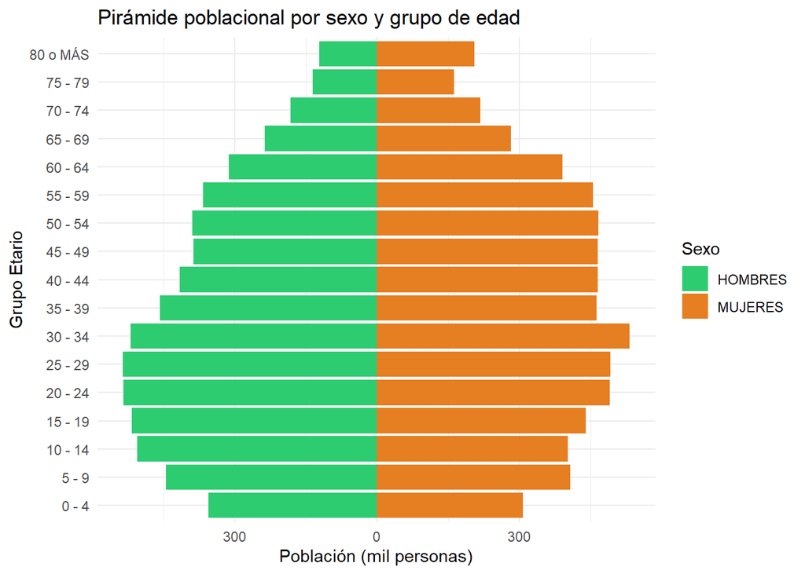

La pirámide poblacional muestra una estructura relativamente joven, con un 17.2% de la población concentrado en grupos etarios de 60 años o más. El grupo etario más numeroso corresponde a ‘30 - 34’. En cuanto a distribución por sexo, se observa un total de aproximadamente 6.415 mil hombres y 6.649 mil mujeres, lo cual evidencia una ligera mayoría femenina. Esta composición etaria y de género puede tener implicancias significativas en la fecundidad y en la planificación de políticas públicas relacionadas con salud, educación y seguridad social.

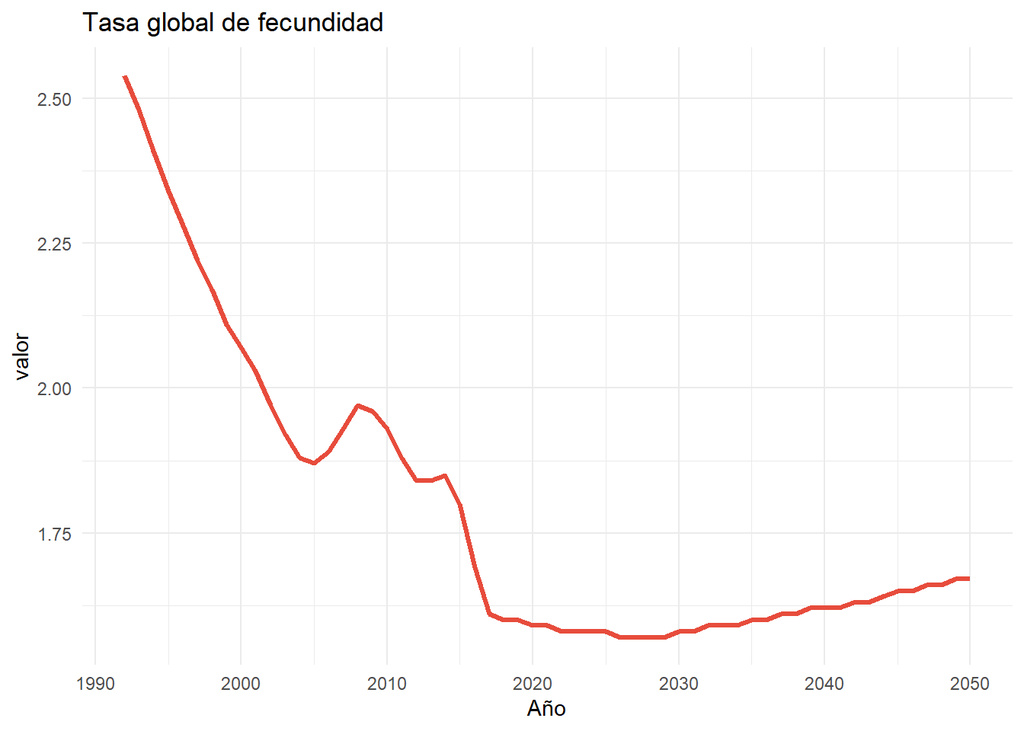

**Análisis descriptivo de la Tasa Global de Fecundidad (TGF):** Entre 1992 y 2050, la TGF evidenció un cambio considerable, al pasar de 2.54 a 1.67 hijos por mujer. Este comportamiento representa una disminución acumulado de 0.87 puntos en el período considerado. Este indicador resume el promedio de hijos por mujer y su evolución temporal es clave para entender los cambios estructurales en la dinámica demográfica del país. Aunque no se infieren causas específicas desde este análisis, el comportamiento observado puede tener implicancias relevantes en áreas como planificación social, diseño de políticas públicas y proyecciones de demanda de servicios en el mediano y largo plazo.

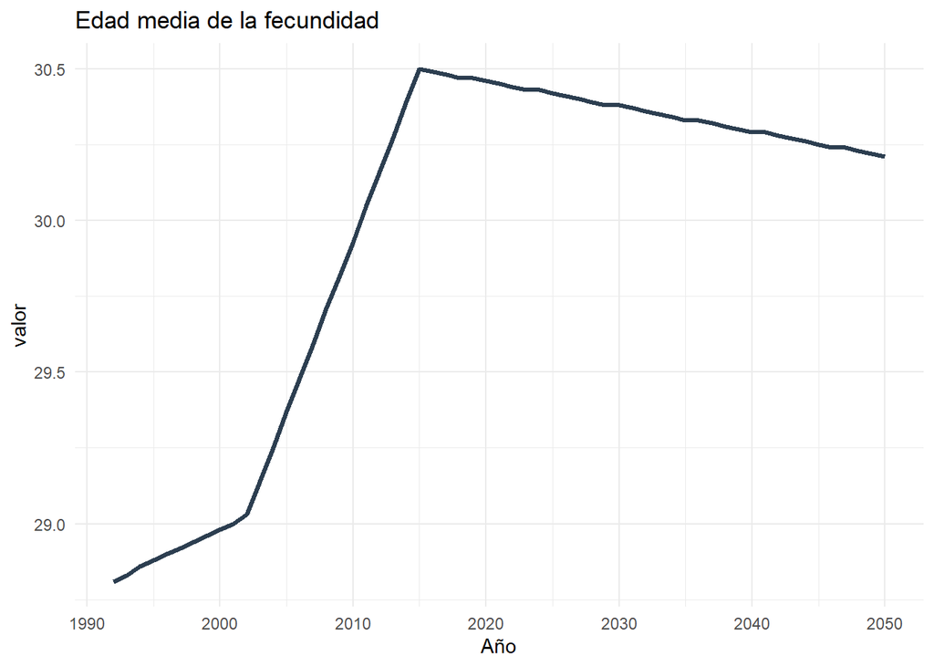

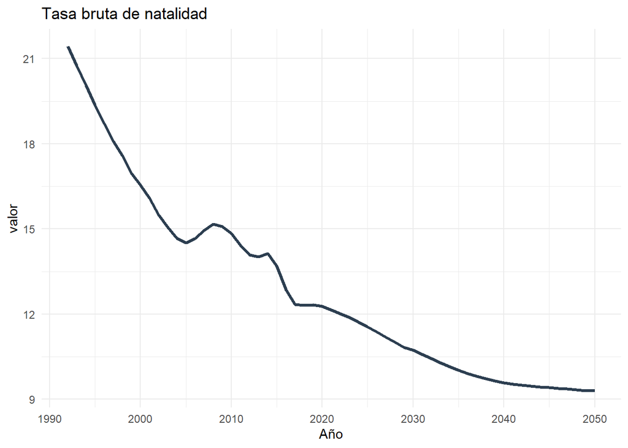

Según las proyecciones del INE, la Tasa Bruta de Natalidad experimentará pronunciada una disminución entre 1992 y 2050, pasando de 21.4 a 9.3 nacimientos por cada 1.000 habitantes. Esta disminución proyectada se alinea con la tendencia de envejecimiento poblacional y menores tasas de fecundidad observadas en las últimas décadas.`

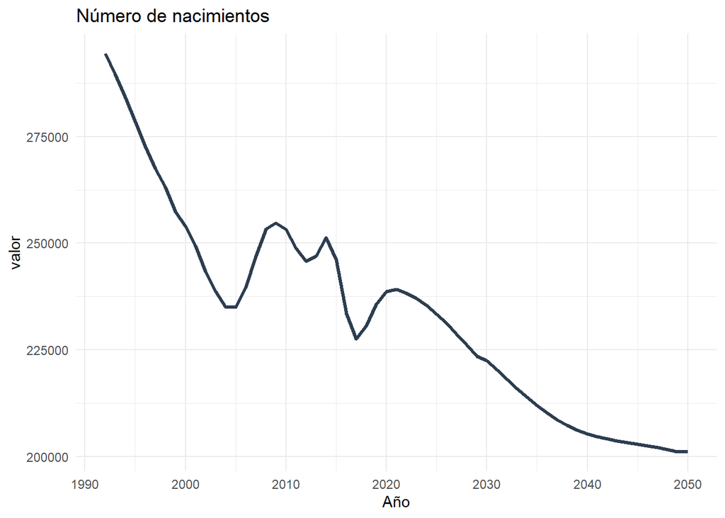

**Análisis descriptivo del Número de Nacimientos:** Entre 1992 y 2050, el total anual de nacimientos evidenció un cambio considerable, pasando de 294,463 a 201,302 nacimientos. Esto representa una disminución absoluta de 93,161 nacimientos en el período analizado. Este comportamiento resulta relevante para proyectar la evolución demográfica futura y para planificar políticas públicas en ámbitos como salud, educación, infraestructura y protección social, donde el volumen de nacimientos es un insumo clave.

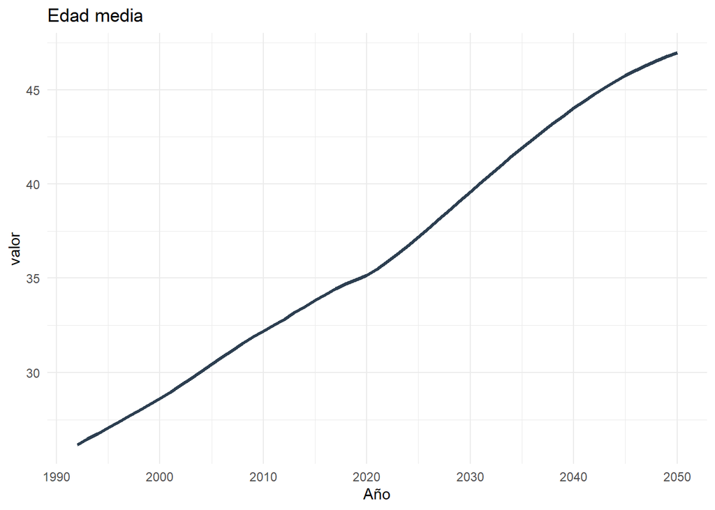

**Análisis descriptivo de la Edad Media de la Población:** Entre 1992 y 2050, la edad media de la población mostró un cambio significativo, pasando de 26.18 a 46.97 años. Este comportamiento representa un aumento de 20.79 años en el período considerado. Este indicador refleja el envejecimiento progresivo de la población, un factor demográfico clave para evaluar la sostenibilidad de los sistemas de salud, pensiones y políticas de cuidado a largo plazo, así como para anticipar cambios en la estructura del mercado laboral.

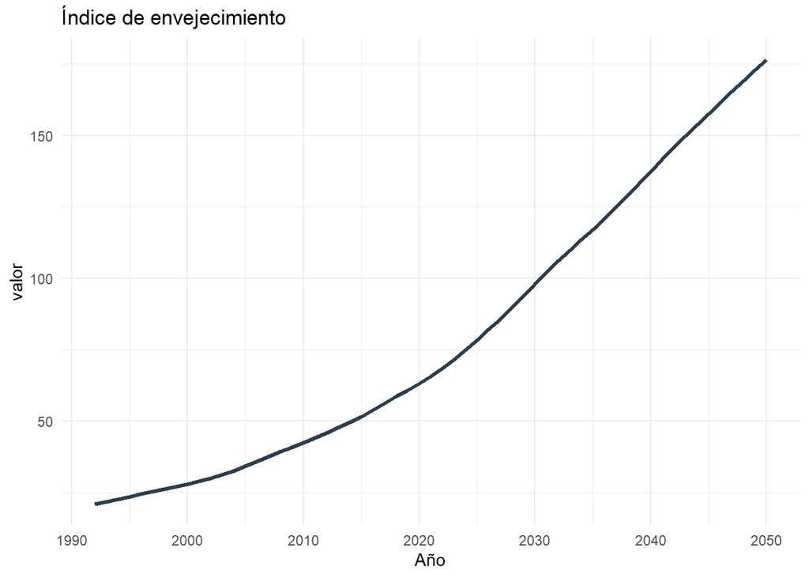

**Análisis descriptivo del Índice de Envejecimiento:** Según las proyecciones demográficas basadas en el Censo 2017, el índice de envejecimiento ha aumentado entre 1992 y 2050, pasando de 21.06 a 176.56 personas mayores de 60 años por cada 100 menores de 15 años. Este indicador refleja el aumento relativo de la población adulta mayor en comparación con la población infantil, lo cual tiene implicancias clave para la planificación de políticas de salud, pensiones y cuidados de largo plazo.

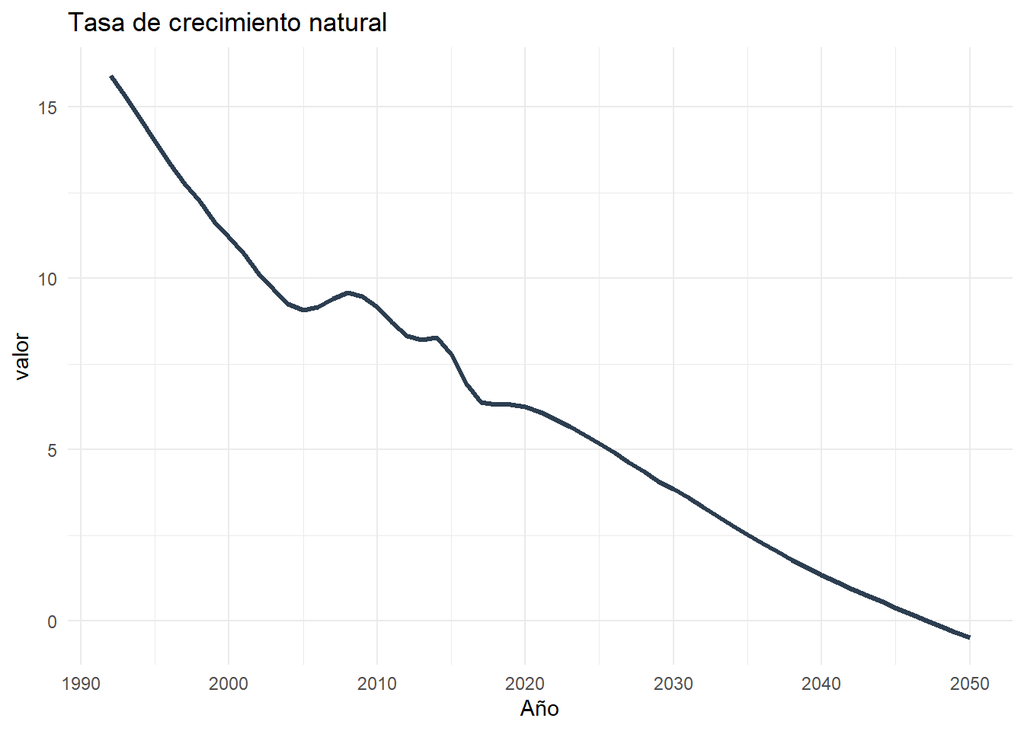

**Análisis descriptivo de la Tasa de Crecimiento Natural:** Entre 1992 y 2050, la tasa de crecimiento natural ha disminuido, pasando de 15.93 a -0.47 por cada mil habitantes. Este indicador, que representa la diferencia entre nacimientos y defunciones sin considerar migraciones, permite visualizar el ritmo de crecimiento poblacional interno del país y es clave para anticipar dinámicas demográficas como el envejecimiento o la necesidad de servicios públicos.

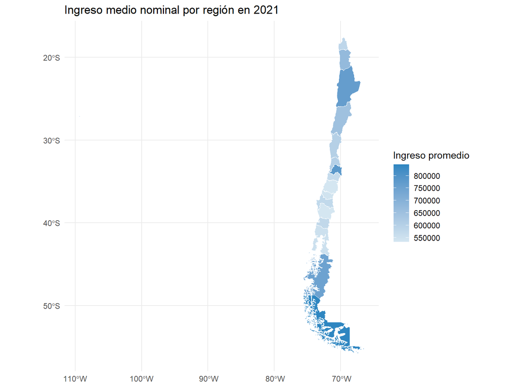

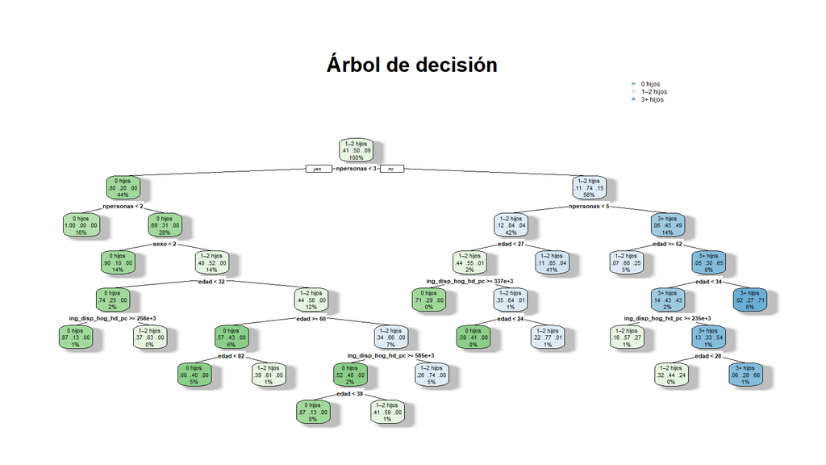

Se construyó un modelo de árbol de decisión para clasificar a los hogares según su número de hijos (0, 1–2 o 3 o más). El árbol reveló que la variable más influyente fue **Tamaño del hogar**, seguida de otras variables sociodemográficas relevantes. La variable más influyente entrega información clave sobre los perfiles familiares. Comprender su impacto permite segmentar y anticipar dinámicas sociodemográficas.

El modelo alcanzó una precisión global de **0.829** (IC 95%: 0.818 – 0.84) y un coeficiente Kappa de **0.697**, lo que indica un desempeño robusto y confiable.

Estos resultados permiten diseñar estrategias segmentadas y basadas en evidencia, como programas de apoyo a hogares grandes, incentivos a la planificación familiar o estrategias diferenciadas según perfiles regionales.

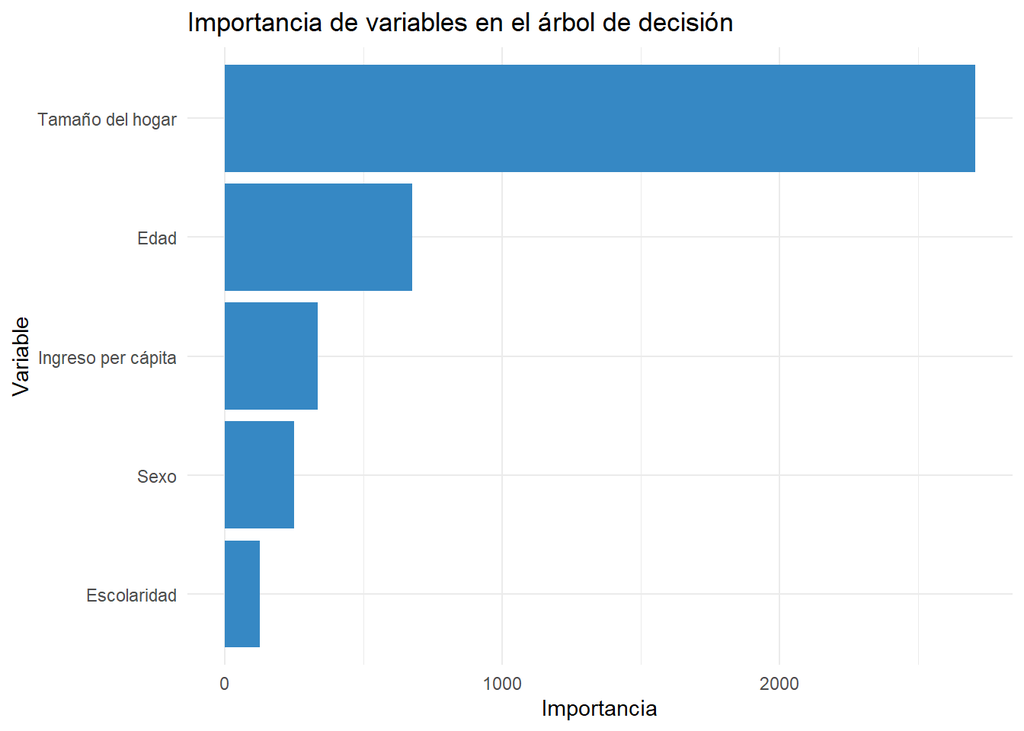

El gráfico anterior presenta la importancia relativa de cada variable utilizada en el modelo de árbol de decisión. Estas variables contribuyen de manera diferenciada a predecir el grupo de número de hijos en un hogar. Las tres variables más influyentes fueron: **Tamaño del hogar**, **Edad** y **Ingreso per cápita**. Esto implica que estas características tienen un fuerte poder explicativo para segmentar a los hogares según su dinámica reproductiva. Por ejemplo, el **Tamaño del hogar** tiene un peso considerable en las decisiones de planificación familiar y en la estructura de los hogares. Estos hallazgos permiten focalizar políticas públicas o decisiones estratégicas en los factores más determinantes. El modelo entrega información procesable para anticipar cambios en la fecundidad y adaptar iniciativas sociales y económicas con base en evidencia.